# main

```python
# Import required packages
import numpy as np
import cv2
import matplotlib.pyplot as plt
from sklearn.metrics import classification_report
from sklearn.linear_model import LogisticRegression

#new packages
import zipfile
import tensorflow as tf
from tensorflow.keras.preprocessing.image import ImageDataGenerator
from tensorflow.keras import layers
from tensorflow.keras import Model
from sklearn.model_selection import train_test_split
import time
import pandas as pd
import time as time
import keras

#Added by Yinan
from sklearn.model_selection import KFold
import torch
import torch.nn as nn
import torch.nn.functional as F
import torch.optim as optim
from torch.utils.data import Dataset
from torch.utils.data import TensorDataset
from torchvision import datasets
from torchvision.transforms import ToTensor
from torch.utils.data import DataLoader
import torchvision
```

## 1. Load the datasets

For the project, we provide a training set with 50000 images in the directory `../data/images/` with:

- noisy labels for all images provided in `../data/noisy_label.csv`;
- clean labels for the first 10000 images provided in `../data/clean_labels.csv`.

```python
# [DO NOT MODIFY THIS CELL]

# load the images
n_img = 50000
n_noisy = 40000
n_clean_noisy = n_img - n_noisy
imgs = np.empty((n_img,32,32,3))
for i in range(n_img):
    img_fn = f'../data/images/{i+1:05d}.png'
    imgs[i,:,:,:]=cv2.cvtColor(cv2.imread(img_fn),cv2.COLOR_BGR2RGB)

# load the labels
clean_labels = np.genfromtxt('../data/clean_labels.csv', delimiter=',', dtype="int32")
noisy_labels = np.genfromtxt('../data/noisy_labels.csv', delimiter=',', dtype="int32")
```

For illustration, we present a small subset (of size 8) of the images with their clean and noisy labels in `clean_noisy_trainset`. You are encouraged to explore more characteristics of the label noises on the whole dataset.

```
Clean labels:
 frog truck truck  deer   car   car  bird horse
Noisy labels:
  cat   dog truck  frog   dog  ship  bird  deer
```

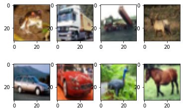

```python
# [DO NOT MODIFY THIS CELL]

fig = plt.figure()

ax1 = fig.add_subplot(2,4,1)
ax1.imshow(imgs[0]/255)
ax2 = fig.add_subplot(2,4,2)
ax2.imshow(imgs[1]/255)
ax3 = fig.add_subplot(2,4,3)
ax3.imshow(imgs[2]/255)
ax4 = fig.add_subplot(2,4,4)
ax4.imshow(imgs[3]/255)
ax1 = fig.add_subplot(2,4,5)
ax1.imshow(imgs[4]/255)
ax2 = fig.add_subplot(2,4,6)
ax2.imshow(imgs[5]/255)
ax3 = fig.add_subplot(2,4,7)
ax3.imshow(imgs[6]/255)
ax4 = fig.add_subplot(2,4,8)
ax4.imshow(imgs[7]/255)

# The class-label correspondence
classes = ('plane', 'car', 'bird', 'cat',
           'deer', 'dog', 'frog', 'horse', 'ship', 'truck')

# print clean labels
print('Clean labels:')
print(' '.join('%5s' % classes[clean_labels[j]] for j in range(8)))
# print noisy labels
print('Noisy labels:')
print(' '.join('%5s' % classes[noisy_labels[j]] for j in range(8)))
```

## 2. The predictive model

We consider a baseline model directly on the noisy dataset without any label corrections. RGB histogram features are extracted to fit a logistic regression model.

### 2.1. Baseline Model

```python
# [DO NOT MODIFY THIS CELL]
# RGB histogram dataset construction
no_bins = 6
bins = np.linspace(0,255,no_bins) # the range of the rgb histogram
target_vec = np.empty(n_img)
feature_mtx = np.empty((n_img,3*(len(bins)-1)))
i = 0
for i in range(n_img):
    # The target vector consists of noisy labels
    target_vec[i] = noisy_labels[i]

    # Use the numbers of pixels in each bin for all three channels as the features
    feature1 = np.histogram(imgs[i][:,:,0],bins=bins)[0]
    feature2 = np.histogram(imgs[i][:,:,1],bins=bins)[0]
    feature3 = np.histogram(imgs[i][:,:,2],bins=bins)[0]

    # Concatenate three features
    feature_mtx[i,] = np.concatenate((feature1, feature2, feature3), axis=None)
    i += 1
```

```python
# [DO NOT MODIFY THIS CELL]
# Train a logistic regression model
clf = LogisticRegression(random_state=0).fit(feature_mtx, target_vec)
```

For the convenience of evaluation, we write the following function `predictive_model` that does the label prediction. **For your predictive model, feel free to modify the function, but make sure the function takes an RGB image of numpy.array format with dimension $32\times32\times3$ as input, and returns one single label as output.**

```python
# [DO NOT MODIFY THIS CELL]
def baseline_model(image):
    '''
    This is the baseline predictive model that takes in the image and returns a label prediction
    '''
    feature1 = np.histogram(image[:,:,0],bins=bins)[0]
    feature2 = np.histogram(image[:,:,1],bins=bins)[0]
    feature3 = np.histogram(image[:,:,2],bins=bins)[0]
    feature = np.concatenate((feature1, feature2, feature3), axis=None).reshape(1,-1)
    return clf.predict(feature)
```

### 2.2. Model I

```python
# Data Splitting and preprocessing

clean_labels = clean_labels.astype(np.int64)
noisy_labels = noisy_labels.astype(np.int64)

x_train1=imgs[:7000,:,:,:]
y_train1 = noisy_labels[:7000]
y_clean1=clean_labels[:7000]

x_train2= imgs[10000:50000,:,:,:]
y_train2 = noisy_labels[10000:50000]

x_test=imgs[7000:10000,:,:,:]
y_test = noisy_labels[7000:10000]
y_clean2=clean_labels[7000:10000]

y_train1=F.one_hot(torch.tensor(y_train1)).numpy()
y_train2= F.one_hot(torch.tensor(y_train2)).numpy()
y_clean1 = F.one_hot(torch.tensor(y_clean1)).numpy()

'''
x_train1=imgs[:7000,:,:,:]
x_train1 = tf.cast(x_train1, dtype='float32')/255.0
y_train1 = noisy_labels[:7000]
y_clean1=clean_labels[:7000]

x_train2= imgs[10000:50000,:,:,:]
x_train2= tf.cast(x_train2, dtype='float32')/255.0
y_train2 = noisy_labels[10000:50000]

x_test=imgs[7000:10000,:,:,:]
y_test = noisy_labels[7000:10000]
y_clean2=clean_labels[7000:10000]

#y_train1 = tf.one_hot(y_train1, depth=10)
y_train2 = tf.one_hot(y_train2, depth=10)
'''
```

[output not shown]

```python
# [BUILD A MORE SOPHISTICATED PREDICTIVE MODEL]

# Model_I generator is for generating an empty untrained modelI structure
def modelI_generator():
    model = tf.keras.Sequential([
        tf.keras.layers.Conv2D(32,(3,3),padding='same',activation ='relu', input_shape=(32,32,3)),
        tf.keras.layers.MaxPooling2D((2,2)),
        #tf.keras.layers.Dropout(0.25),
        tf.keras.layers.Conv2D(64,(3,3),padding='same',activation ='relu'),
        tf.keras.layers.MaxPooling2D((2,2)),
        #tf.keras.layers.Dropout(0.25),
        tf.keras.layers.Conv2D(64,(3,3),padding='same',activation ='relu'),
        tf.keras.layers.Flatten(),
        tf.keras.layers.Dense(64, activation = 'relu'),
        #tf.keras.layers.Dropout(0.5),
        tf.keras.layers.Dense(10, activation = 'softmax')
                                ])
    return model

#Time keeper
class TimeHistory(keras.callbacks.Callback):
    def on_train_begin(self, logs={}):
        self.times = []

    def on_epoch_begin(self, epoch, logs={}):
        self.epoch_time_start = time.time()

    def on_epoch_end(self, epoch, logs={}):
        self.times.append(time.time() - self.epoch_time_start)

time_callback = TimeHistory()

#Start Training
modelI=modelI_generator()
start_time = time.time()
modelI.compile(optimizer= tf.keras.optimizers.Adam(0.001),
                 loss = tf.keras.losses.CategoricalCrossentropy(),
                 metrics = ['accuracy'])
early_stop = tf.keras.callbacks.EarlyStopping(patience=3)
history = modelI.fit(x_train2, y_train2, batch_size= 64,epochs=10,
          validation_split= 0.2, callbacks=[early_stop, time_callback])
print("--- model took %s seconds ---" % (time.time() - start_time))

# Note:Method model_I is only for single/one picture prediction (not for a dataset)
def model_I(image):
    '''
    This function should takes in the image of dimension 32*32*3 as input and returns a label prediction
    '''
    #reshape image into rank 4 tensor
    #takes in one image of (32, 32, 3) and returns label prediction

    image = tf.reshape(image, ((1,) + image.shape))
    predictions = modelI.predict(image)

    return np.argmax(predictions)
```

```
--- model took 169.04705500602722 seconds ---
```

### 2.3. Model II

```python
# [ADD WEAKLY SUPERVISED LEARNING FEATURE TO MODEL I]

 #Build Inception v3 model (Proved to have less accuracy and worse performance than a normal CNN network)
class base_CNN(nn.Module):
    def __init__(self):
        super(base_CNN, self).__init__()
        self.conv1 = nn.Conv2d(in_channels=3, out_channels=32, kernel_size=3,stride=1,padding_mode='zeros')
        self.conv2 = nn.Conv2d(in_channels=32, out_channels=64, kernel_size=3,stride=1,padding_mode='zeros')
        self.pool = nn.MaxPool2d(2, 2)

    def forward(self, x):
        x = self.pool(F.relu(self.conv1(x)))
        x = self.pool(F.relu(self.conv2(x)))
        x = torch.flatten(x, 1) # flatten all dimensions except batch
        return x

#Label_Clean is a model built based on base_CNN and take 'image' and 'noisy_label' as input, clean_label as part of loss function
class Label_Clean(nn.Module):
    def __init__(self,base_CNN):
        super(Label_Clean, self).__init__()
        self.base_CNN=base_CNN
        self.fc11 = nn.LazyLinear(out_features=32)
        self.fc12 = nn.LazyLinear(out_features=32)
        self.fc2 = nn.LazyLinear(out_features=10)

    def forward(self,x1,x2):
        #x1 takes the image, x2 takes the noisy label input
        noisy=x2
        x1=self.base_CNN(x1)
        x1=self.fc11(x1)
        x2=self.fc12(x2)
        x = torch.cat([x1,x2],dim=1)
        x = self.fc2(x)
        x = x+noisy
        return x

#Build Customized Dataset
class Cleandata(Dataset):
    def __init__(self, image ,noisy, clean):
        self.image=image
        self.clean=clean
        self.noisy=noisy

    def __len__(self):
        return len(self.image)

    def __getitem__(self, idx):
        X=self.image[idx,]
        n=self.noisy[idx,]
        c=self.clean[idx,]
        return(X,n,c)

data = Cleandata(x_train1,y_train1,y_clean1)

'''
def collate_fn(data):
    img, noisy, clean = data
    zipped = zip(img, noisy, clean)
    return list(zipped)
'''

#Train the Label Cleaning network based on 7000 human verified data
#Question: batch_size may hugely influence the performance, how to decide proper batch_size?
trainloader = torch.utils.data.DataLoader(dataset=data,batch_size=10,shuffle=True)

CNNnet = base_CNN()
labelnet=Label_Clean(CNNnet)
criterion = nn.CrossEntropyLoss()
optimizer = optim.Adam(labelnet.parameters(), lr=0.001,weight_decay=5e-4)

for epoch in range(20):  # loop over the dataset multiple times
    running_loss = 0.0
    for i, data in enumerate(trainloader, 0):

        #Transfer to torch since the customized CleanDataset use 'numpy'
        inputs, noisy,clean = data
        inputs=np.transpose(inputs.to(torch.float32), (0,3,1,2)) #move channel from postion 3 to position 1
        noisy=noisy.to(torch.float32)
        clean=clean.to(torch.float32)

        # zero the parameter gradients
        optimizer.zero_grad()

        # forward + backward + optimize
        outputs = labelnet(inputs,noisy)
        loss = criterion(outputs,clean)
        loss.backward()
        optimizer.step()

        # print statistics
        running_loss += loss.item()
    print(f'epoch:{epoch + 1} | loss: {running_loss/700:.6f}') #Batch size=10, iteration=700
    running_loss = 0.0
print('Finished Training')

#Save the trained param of base_CNN and label correction network
PATH1 = './CNN_net.pth'
torch.save(CNNnet.state_dict(), PATH1)

PATH2 = './label_net.pth'
torch.save(labelnet.state_dict(), PATH2)
```

```
epoch:1 | loss: 1.952701
epoch:2 | loss: 1.501007
epoch:3 | loss: 1.353922
epoch:4 | loss: 1.222051
epoch:5 | loss: 1.133369
epoch:6 | loss: 1.057348
epoch:7 | loss: 0.975460
epoch:8 | loss: 0.879834
epoch:9 | loss: 0.810916
epoch:10 | loss: 0.752584
epoch:11 | loss: 0.695288
epoch:12 | loss: 0.643793
epoch:13 | loss: 0.596488
epoch:14 | loss: 0.542258
epoch:15 | loss: 0.495683
epoch:16 | loss: 0.500547
epoch:17 | loss: 0.461018
epoch:18 | loss: 0.402491
epoch:19 | loss: 0.414148
epoch:20 | loss: 0.381791
Finished Training
```

```python
#Produce 40000 labels for noisy data (limited CPU requires split training data into 4 subsets)
'''
#new_label1 = labelnet(np.transpose(torch.from_numpy(x_test).to(torch.float32), (0,3,1,2)),torch.from_numpy(y_test).to(torch.float32))
#torch.save(new_label1,"../output/new_label1.pt")
#new_label2 = labelnet(np.transpose(torch.from_numpy(x_train2).to(torch.float32), (0,3,1,2)),torch.from_numpy(y_train2).to(torch.float32))
#torch.save(new_label2,"../output/new_label2.pt")
#new_label3 = labelnet(np.transpose(torch.from_numpy(x_train3).to(torch.float32), (0,3,1,2)),torch.from_numpy(y_train3).to(torch.float32))
#torch.save(new_label3,"../output/new_label3.pt")
#new_label4 = labelnet(np.transpose(torch.from_numpy(x_train4).to(torch.float32), (0,3,1,2)),torch.from_numpy(y_train4).to(torch.float32))
#torch.save(new_label4,"../output/new_label4.pt")
'''

#Produce corrected label
new_label = labelnet(np.transpose(torch.from_numpy(x_train2).to(torch.float32), (0,3,1,2)),torch.from_numpy(y_train2).to(torch.float32))

#output as categorical label (int)
new_label= np.argmax(new_label.detach().numpy(),1)
torch.save(new_label,"../output/new_label_index.pt")
print(new_label)

# output as one_hot
new_label= tf.one_hot(new_label,depth=10)
torch.save(new_label,"../output/new_label_onehot.pt")
print(new_label)
```

```
[9 7 6 ... 9 1 1]
tf.Tensor(
[[0. 0. 0. ... 0. 0. 1.]
 [0. 0. 0. ... 1. 0. 0.]
 [0. 0. 0. ... 0. 0. 0.]
 ...
 [0. 0. 0. ... 0. 0. 1.]
 [0. 1. 0. ... 0. 0. 0.]
 [0. 1. 0. ... 0. 0. 0.]], shape=(40000, 10), dtype=float32)
```

```python
'''
#Model 1 written in Pytorch (size dismatch unsolved)

class Image_Classifier(nn.Module):
    def __init__(self,base_CNN):
        super(Image_Classifier, self).__init__()
        self.base_CNN=base_CNN
        self.fc = nn.LazyLinear(out_features=10)

    def forward(self,x):
        #x takes the image
        x=self.base_CNN(x)
        x=self.fc(x)
        x=F.relu(x)
        return x

#for limieted cpu, use saved new_label
#new_label = torch.tensor( torch.load("../output/new_label.pt"))
x_train2=torch.tensor(x_train2)
new_data =TensorDataset(x_train2,new_label)
new_trainloader = torch.utils.data.DataLoader(dataset=new_data,batch_size=10,shuffle=True)

new_CNNnet = base_CNN()
imagenet =Image_Classifier(new_CNNnet)
criterion = nn.CrossEntropyLoss()
optimizer = optim.Adam(imagenet.parameters(), lr=0.01,weight_decay=5e-4)

for epoch in range(10):  # loop over the dataset multiple times
    running_loss = 0.0
    for i, data in enumerate(new_trainloader, 0):
        inputs, labels = data
        inputs=np.transpose(inputs.to(torch.float32),(0,3,1,2))

        # zero the parameter gradients
        optimizer.zero_grad()

        # forward + backward + optimize
        outputs = imagenet(inputs)
        loss = criterion(outputs,labels)
        loss.backward()
        optimizer.step()

        running_loss += loss.item()
    print(f'epoch:{epoch + 1} | loss: {running_loss/4000:.6f}') #batch_size=10, iteration=4000
    running_loss = 0.0
print('Finished Training')

PATH3 = './image_net.pth'
torch.save(imagenet.state_dict(), PATH3)
'''

#Directly use model1 in tensorflow
modelII = modelI_generator()
start_time = time.time()

modelII.compile(optimizer= tf.keras.optimizers.Adam(0.001),
                 loss = tf.keras.losses.CategoricalCrossentropy(),
                 metrics = ['accuracy'])

early_stop = tf.keras.callbacks.EarlyStopping(patience=3)
time_callback = TimeHistory()
history = modelII.fit(x_train2, new_label, batch_size=200,epochs=10,
          validation_split= 0.2, callbacks=[early_stop, time_callback])

print("--- model took %s seconds ---" % (time.time() - start_time))
```

```
--- model took 129.34231781959534 seconds ---
```

```python
def model_II(img):
    '''
    This function should takes in the image of dimension 32*32*3 as input and returns a label prediction

    #For pytorch model II use
    img=torch.Tensor(img)
    img = torch.reshape(img, ((1,) + img.shape))
    img=np.transpose(img.to(torch.float32), (0,3,1,2))
    predictions = imagenet(img)
    print(predictions)
    predictions = predictions.detach().numpy()
    return np.argmax(predictions)
    '''
    #For tensorflow model II use
    img = tf.reshape(img, ((1,) + img.shape))
    predictions = modelII.predict(img)

    return np.argmax(predictions)
```

## 3. Evaluation

For assessment, we will evaluate your final model on a hidden test dataset with clean labels by the `evaluation` function defined as follows. Although you will not have the access to the test set, the function would be useful for the model developments. For example, you can split the small training set, using one portion for weakly supervised learning and the other for validation purpose.

```python
# [DO NOT MODIFY THIS CELL]
def evaluation(model, test_labels, test_imgs):
    y_true = test_labels
    y_pred = []
    for image in test_imgs:
        y_pred.append(model(image))
    print(classification_report(y_true, y_pred))
```

```python
# [DO NOT MODIFY THIS CELL]
# This is the code for evaluating the prediction performance on a testset
# You will get an error if running this cell, as you do not have the testset
# Nonetheless, you can create your own validation set to run the evlauation
n_test = 10000
test_labels = np.genfromtxt('../data/test_labels.csv', delimiter=',', dtype="int8")
test_imgs = np.empty((n_test,32,32,3))
for i in range(n_test):
    img_fn = f'../data/test_images/test{i+1:05d}.png'
    test_imgs[i,:,:,:]=cv2.cvtColor(cv2.imread(img_fn),cv2.COLOR_BGR2RGB)
evaluation(baseline_model, test_labels, test_imgs)
```

The overall accuracy is $0.24$, which is better than random guess (which should have a accuracy around $0.10$). For the project, you should try to improve the performance by the following strategies:

- Consider a better choice of model architectures, hyperparameters, or training scheme for the predictive model;
- Use both `clean_noisy_trainset` and `noisy_trainset` for model training via **weakly supervised learning** methods. One possible solution is to train a "label-correction" model using the former, correct the labels in the latter, and train the final predictive model using the corrected dataset.
- Apply techniques such as $k$-fold cross validation to avoid overfitting;
- Any other reasonable strategies.

```python
#Evaluation for model I
start = time.time()
evaluation(model_I, y_clean2, x_test)
end = time.time()
print("--- model took %s seconds ---" % (end-start))
```

```
              precision    recall  f1-score   support

           0       0.41      0.50      0.45       312
           1       0.55      0.37      0.44       316
           2       0.21      0.29      0.24       313
           3       0.26      0.10      0.14       320
           4       0.24      0.23      0.23       280
           5       0.23      0.31      0.26       266
           6       0.36      0.26      0.30       305
           7       0.46      0.44      0.45       299
           8       0.49      0.56      0.52       315
           9       0.42      0.57      0.48       274

    accuracy                           0.36      3000
   macro avg       0.36      0.36      0.35      3000
weighted avg       0.37      0.36      0.35      3000

--- model took 125.95629715919495 seconds ---
```

```python
#Evaluation for model II
start = time.time()
evaluation(model_II, y_clean2, x_test)
end = time.time()
print("--- model took %s seconds ---" % (end-start))
```

```
              precision    recall  f1-score   support

           0       0.47      0.68      0.56       312
           1       0.53      0.71      0.61       316
           2       0.49      0.26      0.34       313
           3       0.36      0.39      0.38       320
           4       0.36      0.45      0.40       280
           5       0.45      0.25      0.32       266
           6       0.55      0.43      0.49       305
           7       0.57      0.54      0.55       299
           8       0.71      0.48      0.57       315
           9       0.49      0.70      0.58       274

    accuracy                           0.49      3000
   macro avg       0.50      0.49      0.48      3000
weighted avg       0.50      0.49      0.48      3000

--- model took 116.95833826065063 seconds ---
```

```python
#Save to CSV File for testing dataset
n_test = 10000
test_imgs = np.empty((n_test,32,32,3))
for i in range(n_test):
    img_fn = f'../data/test_images/test{i+1:05d}.png'
    test_imgs[i,:,:,:]=cv2.cvtColor(cv2.imread(img_fn),cv2.COLOR_BGR2RGB)

import numpy as np
import pandas as pd

# reading the csv file
df = pd.read_csv("../data/label_prediction.csv")

# generating predicted values
baseline_model_pred = list()
modelI_pred = list()
modelII_pred = list()

for img in test_imgs:
    baseline_model_pred.append(baseline_model(img))
    modelI_pred.append(modelI(img))
    modelII_pred.append(modelII(img))


# updating the column value/data
df["Baseline"] = baseline_model_pred
df["Model I"] = modelI_pred
df["Model II"] = modelII_pred

# saving the csv to output folder
df.to_csv("../output/label_prediction.csv")
```